# r-math-derivative

R中求导与求极值

Go back

# r-math-derivative

YuDalang

2016-09-26

> 这里记录一下怎么用R来求导的过程，但是这里我侧重的是用R直接来进行求导的技术

# 使用的函数：在R的基本包stats中三个基本的函数可以用来进行求导

```
D (expr, name)
deriv(expr, ...)
deriv3(expr, ...)
```

D is modelled after its S namesake for taking simple symbolic derivatives.

D()是直接做符号运算的。

deriv is a generic function with a default and a formula method. It returns a call for computing the expr and its (partial) derivatives, simultaneously. It uses so-called algorithmic derivatives. If function.arg is a function, its arguments can have default values, see the fx example below.

## Arguments

[output not shown]

# 教程1

摘自： http://blog.fens.me/r-math-derivative/

## 1.根据实例演示

```r
dx <- deriv(y ~ x^3, "x") ; dx # 生成导数公式
```

```
## expression({
##     .value <- x^3
##     .grad <- array(0, c(length(.value), 1L), list(NULL, c("x")))
##     .grad[, "x"] <- 3 * x^2
##     attr(.value, "gradient") <- .grad
##     .value
## })
```

```r
mode(dx) # 查看dx 变量类型
```

```
## [1] "expression"
```

```r
x<-1:2 # 给自变量x 赋值
eval(dx) # 运行求导计算
```

```
## [1] 1 8
## attr(,"gradient")
##       x
## [1,]  3
## [2,] 12
```

```r
# 原函数的计算结果和使用梯度下降法，导函数的计算结果
# x=1,dx=3*1^2=3
# x=2,dx=3*2^2=12
```

我们使用deriv(expr, name)函数时通常要传2 个参数，第一参数expr 就是原函数公式，用~号 来分隔公式的两边，第二参数name 用于指定函数的自变量。deriv()函数会返回一个表达式 expression 类型变量，再用eval()函数运行这个表达式得到就可得到计算结果，如上面的代码实 现。

**如果希望以函数的形式调用计算公式，那么你还需要传第三个参数func，并让func 参数为TRUE**

参考下面的代码实现。

```r
# 计算正弦函数y=sin(x)的导数，根据导数计算公式，用于手动计算的变形结果为 y’=cos(x)，当x=pi 时，y’=-1，当x=4*pi 时，y’=1，其中pi=π 表示圆周率。

dx <- deriv(y ~ sin(x), "x", func= TRUE) ; dx # 生成导数公式的调用函数
```

```
## function (x)
## {
##     .value <- sin(x)
##     .grad <- array(0, c(length(.value), 1L), list(NULL, c("x")))
##     .grad[, "x"] <- cos(x)
##     attr(.value, "gradient") <- .grad
##     .value
## }
```

```r
mode(dx) # 检查dx 的类型
```

```
## [1] "function"
```

```r
dx(c(pi,4*pi)) # 以参数作为自变量，进行函数调用
```

```
## [1]  1.224606e-16 -4.898425e-16
## attr(,"gradient")
##       x
## [1,] -1
## [2,]  1
```

```r
# 导函数的计算结果
# x=pi,dx=cos(pi)=-1
# x=4*pi,dx=cos(4*pi)=1
```

## 2.二阶导数计算

比如，计算 y=sin(a*x) 函数的二阶导数导数y”，其中a 为常数，根据导数计算公式，用于手动 计算的变形结果为一阶导数为$y’=a*cos(a*x)$，对y’再求导公式变形为，$y”=-a^2*sin(a*x)$

用R 语言进行程序实现

```r
a<-2 # 设置a 的值
dx<-deriv(y~sin(a*x),"x",func = TRUE) # 生成一阶导数公式
dx(pi/3) # 计算一阶导数
```

```
## [1] 0.8660254
## attr(,"gradient")
##       x
## [1,] -1
```

```r
# 导函数计算结果y'= a*cos(a*x)=2*cos(2*pi/3)=-1
dx<-deriv(y~a*cos(a*x),"x",func = TRUE) # 对一阶导函数求导
dx(pi/3)
```

```
## [1] -1
## attr(,"gradient")
##              x
## [1,] -3.464102
```

```r
# 导函数计算结果y'= -a^2*sin(a*x)=-2^2*sin(2*pi/3)=-3.464102
```

上面二阶导数的计算，我们是动手划分为两次求导进行计算的，利用deriv3()函数其实合并成一步计算。

```r
dx<-deriv3(y~sin(a*x),"x",func = TRUE) # 生成二阶导数公式
dx(pi/3) # 计算导数
```

```
## [1] 0.8660254
## attr(,"gradient")
##       x
## [1,] -1
## attr(,"hessian")
## , , x
##
##              x
## [1,] -3.464102
```

```r
#前面是一阶导数的结果，后面是二阶导数的结果
```

# 3.D 方法

D 方法与 deriv 的最大不同之处在于其返回类型为“call”类型，这也意味着它更容易嵌入在其他方法中被引用。其次它能够求取二阶偏导。再者 D 方法的嵌套使用可以求取任意高阶导数。最后 D 的结果要比 deriv 的结果直观一些，deriv 常会把返回的表达式转换成复合表达式的形式，不如 D 方法显示结果直接。

# 4.高阶求导

```r
## Higher derivatives:
DD <- function(expr, name, order = 1) {
   if(order < 1) stop("'order' must be >= 1")
   if(order == 1) D(expr, name)
   else DD(D(expr, name), name, order - 1)
}
DD(expression(sin(x^2)), "x", 3)
```

```
## -(sin(x^2) * (2 * x) * 2 + ((cos(x^2) * (2 * x) * (2 * x) + sin(x^2) *
##     2) * (2 * x) + sin(x^2) * (2 * x) * 2))
```

```r
#教程自带的例子
# 如果你要求sin(x^2)在x=3时的三阶导数的值
x=3
eval(DD(expression(sin(x^2)), "x", 3))
```

```
## [1] 181.9679
```

### 自带的教程

```r
## formula argument :
dx2x <- deriv(~ x^2, "x") ; dx2x
#the same as: dx2x <- deriv(expr=~ x^2, name="x")

mode(dx2x)
x <- -1:2
eval(dx2x)#程序自动会读取x这个变量的值

## Something 'tougher':
trig.exp <- expression(sin(cos(x + y^2)))
( D.sc <- D(trig.exp, "x") )
all.equal(D(trig.exp[[1]], "x"), D.sc)

( dxy <- deriv(trig.exp, c("x", "y")) )
y <- 1
eval(dxy)
eval(D.sc)

## function returned:
deriv((y ~ sin(cos(x) * y)), c("x","y"), func = TRUE)

## function with defaulted arguments:
(fx <- deriv(y ~ b0 + b1 * 2^(-x/th), c("b0", "b1", "th"),
             function(b0, b1, th, x = 1:7){} ) )
fx(2, 3, 4)

## Higher derivatives
deriv3(y ~ b0 + b1 * 2^(-x/th), c("b0", "b1", "th"),
     c("b0", "b1", "th", "x") )

## Higher derivatives:
DD <- function(expr, name, order = 1) {
   if(order < 1) stop("'order' must be >= 1")
   if(order == 1) D(expr, name)
   else DD(D(expr, name), name, order - 1)
}
DD(expression(sin(x^2)), "x", 3)
## showing the limits of the internal "simplify()" :
## Not run:
-sin(x^2) * (2 * x) * 2 + ((cos(x^2) * (2 * x) * (2 * x) + sin(x^2) *
    2) * (2 * x) + sin(x^2) * (2 * x) * 2)

## End(Not run)
```

# 5.最后还有一个内容就是求极值

导数求好了，当然还要求驻点了，所以现在再学一个函数。求解方程根公式uniroot(f,interval,lower=min(interval),upper=max(interval),tol=,maxiter=,)

```r
## some platforms hit zero exactly on the first step:
## if so the estimated precision is 2/3.
f <- function (x, a) x - a
str(xmin <- uniroot(f, c(0, 1), tol = 0.0001, a = 1/3))
```

```
## List of 5
##  $ root      : num 0.333
##  $ f.root    : num 0
##  $ iter      : int 1
##  $ init.it   : int NA
##  $ estim.prec: num 0.667
```

```r
#等同于str(xmin <- uniroot(f=f, interval=c(0, 1), tol = 0.0001, a = 1/3))
# 其中，f表示要求解方程，interval表示包含方程根的初始区间，lower表示interval中方程根初始区间的左端点，upper表示右端点，tol是想要达到的计算精度，maxiter是设置的最大迭代次数。
```

通过uniroot()函数就求得了方程$f(x)=x-1/3=0$的一个根

```r
## handheld calculator example: fixed point of cos(.):
uniroot(function(x) cos(x) - x, lower = -pi, upper = pi, tol = 1e-9)$root
```

```
## [1] 0.7390851
```

```r
str(uniroot(function(x) x*(x^2-1) + .5, lower = -2, upper = 2,
            tol = 0.0001))
```

```
## List of 5
##  $ root      : num -1.19
##  $ f.root    : num -2.55e-07
##  $ iter      : int 7
##  $ init.it   : int NA
##  $ estim.prec: num 5e-05
```

```r
str(uniroot(function(x) x*(x^2-1) + .5, lower = -2, upper = 2,
            tol = 1e-10))
```

```
## List of 5
##  $ root      : num -1.19
##  $ f.root    : num 5.67e-11
##  $ iter      : int 8
##  $ init.it   : int NA
##  $ estim.prec: num 5e-11
```

```r
## Find the smallest value x for which exp(x) > 0 (numerically):
r <- uniroot(function(x) 1e80*exp(x) - 1e-300, c(-1000, 0), tol = 1e-15)
str(r, digits.d = 15) # around -745, depending on the platform.
```

```
## List of 5
##  $ root      : num -745
##  $ f.root    : num -1e-300
##  $ iter      : int 70
##  $ init.it   : int NA
##  $ estim.prec: num 3.41060513164848e-13
```

```r
exp(r$root)     # = 0, but not for r$root * 0.999...
```

```
## [1] 0
```

```r
minexp <- r$root * (1 - 10*.Machine$double.eps)
exp(minexp)     # typically denormalized
```

```
## [1] 4.940656e-324
```

## rootsolve包中的uniroot.all函数

```r
library(rootSolve)
uniroot.all(function(x) x^4-10*x^3+35*x^2-50*x+24,c(0,5))
```

```
## [1] 1 2 3 4
```

```r
uniroot.all(function(x) x^4-10*x^3+35*x^2-50*x+24,c(-1,10))
```

```
## [1] 0.9999999 2.0000189 3.0000053 3.9999991
```

```r
uniroot.all(function(x) x^4-10*x^3+35*x^2-50*x+24,c(-10,10))
```

```
## [1] 1 2 3 4
```

```r
uniroot.all(function(x) x^4-10*x^3+35*x^2-50*x+24,c(-100,100))
```

```
## [1] 2 4
```

#### 自带的教程

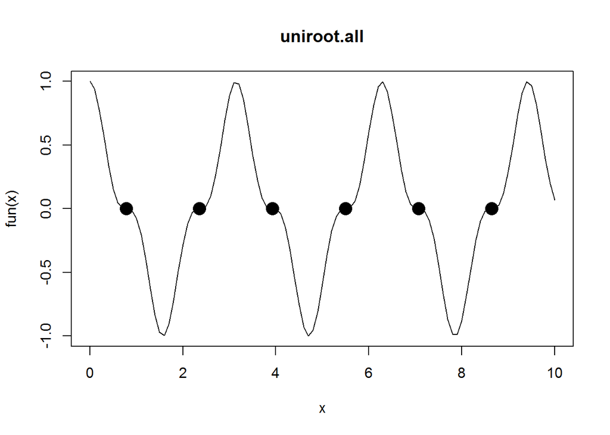

```r
## =======================================================================
##   Mathematical examples
## =======================================================================

# a well-behaved case...
fun <- function (x) cos(2*x)^3

curve(fun(x), 0, 10,main = "uniroot.all")

All <- uniroot.all(fun, c(0, 10))
points(All, y = rep(0, length(All)), pch = 16, cex = 2)
```

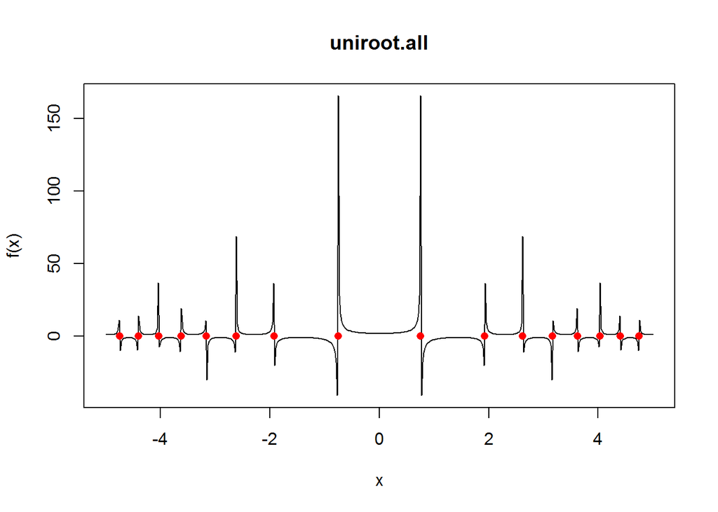

```r
# a difficult case...
f <- function (x) 1/cos(1+x^2)
AA <- uniroot.all(f, c(-5, 5))
curve(f(x), -5, 5, n = 500, main = "uniroot.all")
points(AA, rep(0, length(AA)), col = "red", pch = 16)
```

```r
f(AA)  # !!!
```

```
##  [1]  2208.227  1811.285  1741.080 -2735.492 -2273.341  3422.914  2635.566
##  [8] 11794.351 11794.351  2635.566  3422.914 -2273.341 -2735.492  1741.080
## [15]  1811.285  2208.227
```

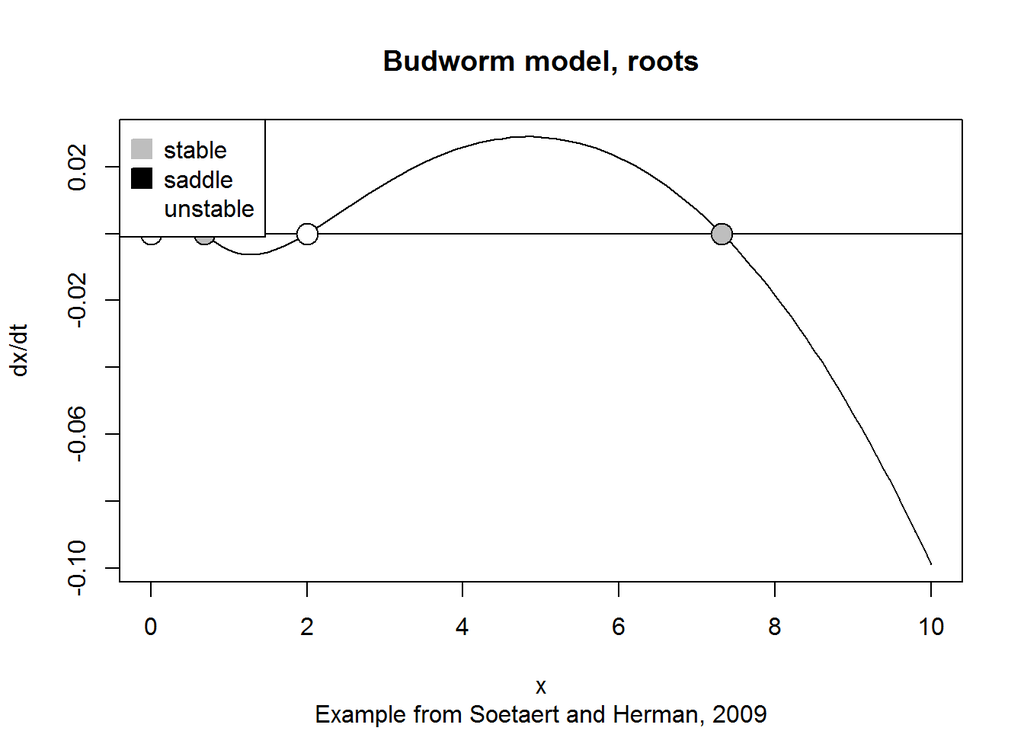

```r
## =======================================================================
## Ecological modelling example
## =======================================================================

# Example from the book of Soetaert and Herman(2009)
# A practical guide to ecological modelling -
# using R as a simulation platform. Springer

r   <- 0.05
K   <- 10
bet <- 0.1
alf <- 1

# the model : density-dependent growth and sigmoid-type mortality rate
rate <- function(x, r = 0.05) r*x*(1-x/K) - bet*x^2/(x^2+alf^2)

# find all roots within the interval [0,10]
Eq   <- uniroot.all(rate, c(0, 10))

# jacobian evaluated at all roots:
# This is just one value - and therefore jacobian = eigenvalue
# the sign of eigenvalue: stability of the root: neg=stable, 0=saddle, pos=unstable

eig <- vector()
for (i in 1:length(Eq))
  eig[i] <- sign (gradient(rate, Eq[i]))

curve(rate(x), ylab = "dx/dt", from = 0, to = 10,
      main = "Budworm model, roots",
      sub = "Example from Soetaert and Herman, 2009")
abline(h = 0)
points(x = Eq, y = rep(0, length(Eq)), pch = 21, cex = 2,
       bg = c("grey", "black", "white")[eig+2] )
legend("topleft", pch = 22, pt.cex = 2,
       c("stable", "saddle", "unstable"),
       col = c("grey", "black", "white"),
       pt.bg = c("grey", "black", "white"))
```

```r
## =======================================================================
## Vectorisation:
## =======================================================================
# from R-help Digest, Vol 130, Issue 27
#https://stat.ethz.ch/pipermail/r-help/2013-December/364799.html

integrand1 <- function(x) 1/x*dnorm(x)
integrand2 <- function(x) 1/(2*x-50)*dnorm(x)
integrand3 <- function(x, C) 1/(x+C)

res <- function(C) {
  integrate(integrand1, lower = 1, upper = 50)$value +
  integrate(integrand2, lower = 50, upper = 100)$value -
  integrate(integrand3, C = C, lower = 1, upper = 100)$value
}

# uniroot passes one value at a time to the function, so res can be used as such
uniroot(res, c(1, 1000))
```

```
## $root
## [1] 837.0516
##
## $f.root
## [1] 1.622351e-11
##
## $iter
## [1] 9
##
## $init.it
## [1] NA
##
## $estim.prec
## [1] 6.103516e-05
```

```r
# Need to vectorise the function to use uniroot.all:
res <- Vectorize(res)
uniroot.all(res, c(1,1000))
```

```
## [1] 837.0516
```